# Introduction to roclab

```r
library(roclab)
```

# Overview

The **roclab** package implements ROC-Optimizing Binary Classifiers, supporting both linear and kernel models.

- **Linear models** provide various regularization penalties (ridge, lasso, alasso, elastic net, scad, mcp).
- **Kernel models** support flexible kernel functions (radial, polynomial, linear, laplace).
- **Both models** include several surrogate loss functions (hinge, hinge2 (squared hinge), logistic, exponential).

For large-scale data, the model is computationally prohibitive because its loss is a U-statistic involving a double summation. To reduce this burden, the package adopts an efficient algorithm based on an incomplete U-statistic, which approximates the loss with a single summation. In kernel models, a Nyström low-rank approximation is further applied to efficiently compute the kernel matrix. These approximations substantially reduce computational cost and accelerate training, while maintaining accuracy, making ROC-Optimizing Binary Classifiers practical for large-scale datasets.

In addition, efficient optimization is performed using **Gradient Descent with the Adamax update rule** —a variant of Adam, based on the infinity norm—for linear models with the ridge penalty and kernel models. For linear models with other penalties (i.e., those involving variable selection), **Proximal Gradient Descent with an Adamax adaptive learning rate scheme** is employed.

# Example: Linear Model

```r
set.seed(123)
n_lin_train <- 1200
n_pos_lin <- round(0.2 * n_lin_train )
n_neg_lin <- n_lin_train  - n_pos_lin

X_train_lin <- rbind(
  matrix(rnorm(2 * n_neg_lin, mean = -1), ncol = 2),
  matrix(rnorm(2 * n_pos_lin, mean =  1), ncol = 2)
)
y_train_lin <- c(rep(-1, n_neg_lin), rep(1, n_pos_lin))

# Fit a linear model
fit_lin <- roclearn(X_train_lin, y_train_lin, lambda = 0.1)

# Summary
summary(fit_lin)
```

```
#> Linear Model Summary
#> ----------------------
#> Call:
#> roclearn(X = X_train_lin, y = y_train_lin, lambda = 0.1)
#>
#> Number of observations: 1200
#> Number of predictors: 2
#>
#> Penalty: ridge
#> Lambda: 0.1
#> Loss function: hinge
#> Approximation: Yes (B = 1200 )
#>
#> Intercept: -0.0678
#> Converged: TRUE
#> Iterations: 1179
#> Training time (sec): 0.05
#>
#> Coefficients (first 10):
#>        V1        V2
#> 0.4726011 0.4684517
```

```r
n_test_lin <- 300
n_pos_test_lin <- round(0.2 * n_test_lin)
n_neg_test_lin <- n_test_lin - n_pos_test_lin
X_test_lin <- rbind(
  matrix(rnorm(2 * n_neg_test_lin, mean = -1), ncol = 2),
  matrix(rnorm(2 * n_pos_test_lin, mean =  1), ncol = 2)
)
y_test_lin <- c(rep(-1, n_neg_test_lin), rep(1, n_pos_test_lin))

# Predict decision scores on the test set
pred_score_lin <- predict(fit_lin, X_test_lin, type = "response")
head(pred_score_lin)
```

```
#> [1] -1.7635218 -1.3635854 -0.8779351 -1.4472523 -0.1029838 -1.2500200
```

```r
# Predict classes {-1, 1} on the test set
pred_class_lin <- predict(fit_lin, X_test_lin, type = "class")
head(pred_class_lin)
```

```
#> [1] -1 -1 -1 -1 -1 -1
```

```r
# AUC on the test set
auc(fit_lin, X_test_lin, y_test_lin)
```

```
#> [1] 0.9763194
```

[output not shown]

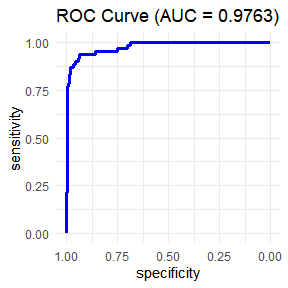

```r
# Plot ROC curve on the test set
plot_roc(y_test_lin, pred_score_lin)
```

# Example: Kernel Model

```r
set.seed(123)
n_ker <- 1200
r_train_ker <- sqrt(runif(n_ker, 0.05, 1))
theta_train_ker <- runif(n_ker, 0, 2*pi)
X_train_ker <- cbind(r_train_ker * cos(theta_train_ker), r_train_ker * sin(theta_train_ker))
y_train_ker <- ifelse(r_train_ker < 0.5, 1, -1)

# Fit a kernel model
fit_ker <- kroclearn(X_train_ker, y_train_ker, lambda = 0.1, kernel = "radial")

# Summary
summary(fit_ker)
```

```
#> Kernel Model Summary
#> -----------------------------
#> Call:
#> kroclearn(X = X_train_ker, y = y_train_ker, lambda = 0.1, kernel = "radial")
#>
#> Number of observations: 1200
#> Number of predictors: 2
#>
#> Kernel: radial
#> Kernel parameter: 0.5
#> Lambda: 0.1
#> Loss function: hinge
#> Approximation: Yes (Nystrom, B = 1200 )
#>   Nystrom landmarks: 35
#>
#> Intercept: -1.4187
#> Converged: TRUE
#> Iterations: 1117
#> Training time (sec): 0.5
#>
#> Theta coefficients (first 10):
#>  [1]  0.07866332 -0.03783574  0.10868490  0.37010068  0.09839754 -0.03419196
#>  [7]  0.34827559  0.46628109  0.15124239  1.07986830
#> ...
```

```r
n_test_ker <- 300
r_test_ker <- sqrt(runif(n_test_ker, 0.05, 1))
theta_test_ker <- runif(n_test_ker, 0, 2*pi)
X_test_ker <- cbind(r_test_ker * cos(theta_test_ker), r_test_ker * sin(theta_test_ker))
y_test_ker <- ifelse(r_test_ker < 0.5, 1, -1)

# Predict decision scores on the test set
pred_score_ker <- predict(fit_ker, X_test_ker, type = "response")
head(pred_score_ker)
```

```
#> [1]  0.28910462 -0.07075436 -0.17158776 -0.59294103  0.06180517 -0.12245284
```

```r
# Predict classes {-1, 1} on the test set
pred_class_ker <- predict(fit_ker, X_test_ker, type = "class")
head(pred_class_ker)
```

```
#> [1]  1 -1 -1 -1  1 -1
```

```r
# AUC on the test set
auc(fit_ker, X_test_ker, y_test_ker)
```

```
#> [1] 0.9942396
```

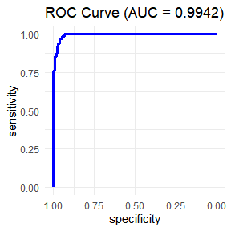

```r
# Plot ROC curve on the test set
plot_roc(y_test_ker, pred_score_ker)
```

# Cross-Validation

```r
# 5-fold CV for linear models
cvfit_lin <- cv.roclearn(
  X_train_lin, y_train_lin,
  lambda.vec = exp(seq(log(0.01), log(5), length.out = 20)),
  nfolds = 5
)

# Summarize the cross-validation result
summary(cvfit_lin)
```

```
#> Cross-validated Linear Model
#> -----------------------
#> Loss: hinge
#> Penalty: ridge
#> Number of folds: 5
#> Number of candidate lambdas: 20
#>
#> Optimal lambda: 0.05131629
#> Cross-validated AUC at optimal lambda: 0.9694 (+/- 0.0103)
#>
#> Overall AUC (mean +/- sd) across lambdas:
#>    lambda auc.mean auc.sd
#> 1  0.0100   0.9687 0.0099
#> 2  0.0139   0.9687 0.0096
#> 3  0.0192   0.9688 0.0095
#> 4  0.0267   0.9690 0.0104
#> 5  0.0370   0.9690 0.0100
#> 6  0.0513   0.9694 0.0103
#> 7  0.0712   0.9688 0.0106
#> 8  0.0987   0.9692 0.0104
#> 9  0.1370   0.9692 0.0102
#> 10 0.1900   0.9692 0.0103
#> ...
```

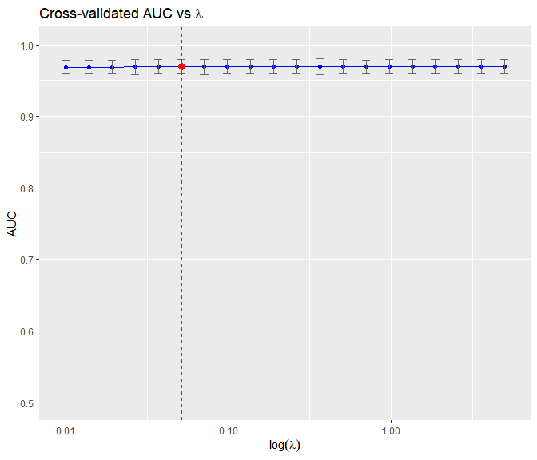

```r
# Plot the cross-validation AUC across lambda values
plot(cvfit_lin)
```

```r
# 5-fold CV for kernel models
cvfit_ker <- cv.kroclearn(
  X_train_ker, y_train_ker,
  lambda.vec = exp(seq(log(0.01), log(5), length.out = 20)),
  kernel = "radial",
  nfolds = 5
)

# Summarize the cross-validation result
summary(cvfit_ker)
```

```
#> Cross-validated Kernel Model
#> ------------------------------
#> Loss: hinge
#> Kernel: radial
#> Number of folds: 5
#> Number of candidate lambdas: 20
#>
#> Optimal lambda: 0.01386919
#> Cross-validated AUC at optimal lambda: 0.9994 (+/- 0.0005)
#>
#> Overall AUC (mean +/- sd) across lambdas:
#>    lambda auc.mean auc.sd
#> 1  0.0100   0.9981 0.0031
#> 2  0.0139   0.9994 0.0005
#> 3  0.0192   0.9984 0.0025
#> 4  0.0267   0.9992 0.0012
#> 5  0.0370   0.9986 0.0018
#> 6  0.0513   0.9987 0.0016
#> 7  0.0712   0.9972 0.0017
#> 8  0.0987   0.9947 0.0047
#> 9  0.1370   0.9868 0.0136
#> 10 0.1900   0.9833 0.0076
#> ...
```

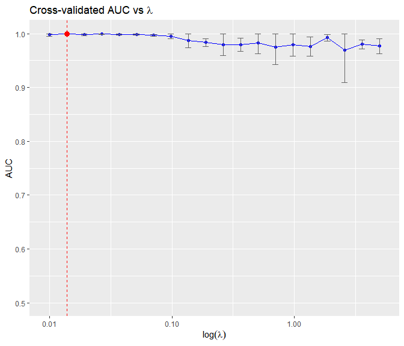

```r
# Plot the cross-validation AUC across lambda values
plot(cvfit_ker)
```

# Real Data Example 1: Ionosphere

```r
library(mlbench)
data(Ionosphere)

# Prepare data
X_iono <- Ionosphere[, -35]
y_iono <- ifelse(Ionosphere$Class == "bad", 1, -1)

set.seed(123)
train_idx <- sample(seq_len(nrow(X_iono)), size = 200)
X_train_iono <- X_iono[train_idx, ]
y_train_iono <- y_iono[train_idx]
X_test_iono  <- X_iono[-train_idx, ]
y_test_iono  <- y_iono[-train_idx]

# Fit a linear model
fit_iono_lin <- roclearn(X_train_iono, y_train_iono, lambda = 0.1, approx=TRUE)
summary(fit_iono_lin)
```

```
#> Linear Model Summary
#> ----------------------
#> Call:
#> roclearn(X = X_train_iono, y = y_train_iono, lambda = 0.1, approx = TRUE)
#>
#> Number of observations: 200
#> Number of predictors: 33
#>
#> Penalty: ridge
#> Lambda: 0.1
#> Loss function: hinge
#> Approximation: Yes (B = 200 )
#>
#> Intercept: 1.3041
#> Converged: TRUE
#> Iterations: 1164
#> Training time (sec): 0.07
#>
#> Coefficients (first 10):
#>          V3          V4          V5          V6          V7          V8
#> -0.40674510 -0.18973373 -0.42204641 -0.22075386 -0.17022688 -0.43640505
#>          V9         V10         V11         V12
#> -0.12857765 -0.24904508  0.08956809 -0.11456464
#> ...
#>
#> Categorical variables dummy-encoded:
#> [1] "V1"
#> Removed columns:
#> [1] "V2"
```

```r
# Predict decision scores on the test set
pred_score_iono_lin <- predict(fit_iono_lin, X_test_iono, type = "response")
head(pred_score_iono_lin)
```

```
#> [1]  0.7813989 -0.4333132  1.0361641  1.5973041  0.2972169 -0.4974081
```

```r
# Predict classes {-1, 1} on the test set
pred_class_iono_lin <- predict(fit_iono_lin, X_test_iono, type = "class")
head(pred_class_iono_lin)
```

```
#> [1]  1 -1  1  1  1 -1
```

```r
# AUC on the test set
auc(fit_iono_lin, X_test_iono, y_test_iono)
```

```
#> [1] 0.9184803
```

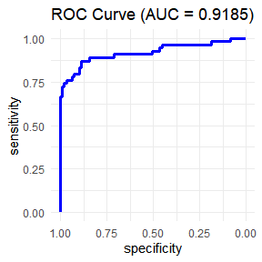

```r
# Plot ROC curve on the test set
plot_roc(y_test_iono, pred_score_iono_lin)
```

```r
# 5-fold CV for linear models
cvfit_iono_lin <- cv.roclearn(
  X_train_iono, y_train_iono,
  lambda.vec = exp(seq(log(0.01), log(5), length.out = 10)),
  approx=TRUE, nfolds=5)
summary(cvfit_iono_lin)
```

```
#> Cross-validated Linear Model
#> -----------------------
#> Loss: hinge
#> Penalty: ridge
#> Number of folds: 5
#> Number of candidate lambdas: 10
#>
#> Optimal lambda: 0.3158114
#> Cross-validated AUC at optimal lambda: 0.8633 (+/- 0.0965)
#>
#> Overall AUC (mean +/- sd) across lambdas:
#>    lambda auc.mean auc.sd
#> 1  0.0100   0.8072 0.1232
#> 2  0.0199   0.8236 0.1222
#> 3  0.0398   0.8408 0.0943
#> 4  0.0794   0.8624 0.0794
#> 5  0.1580   0.8501 0.0866
#> 6  0.3160   0.8633 0.0965
#> 7  0.6300   0.8489 0.0896
#> 8  1.2600   0.8250 0.1270
#> 9  2.5100   0.8068 0.1361
#> 10 5.0000   0.7776 0.1213
```

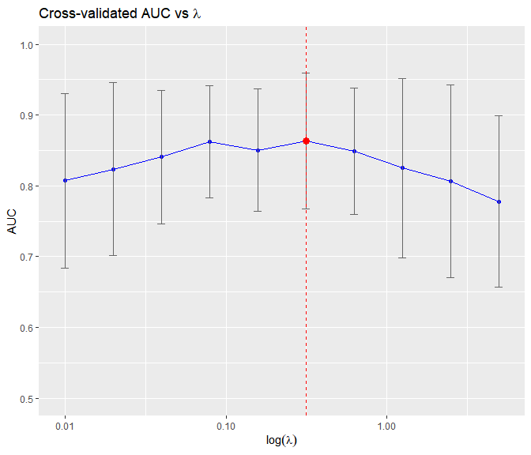

```r
# Plot the cross-validation AUC across lambda values
plot(cvfit_iono_lin)
```

```r
# Fit a kernel model
fit_iono_ker <- kroclearn(X_train_iono, y_train_iono, lambda = 0.1, kernel = "radial", approx=TRUE)
summary(fit_iono_ker)
```

```
#> Kernel Model Summary
#> -----------------------------
#> Call:
#> kroclearn(X = X_train_iono, y = y_train_iono, lambda = 0.1, kernel = "radial",
#>     approx = TRUE)
#>
#> Number of observations: 200
#> Number of predictors: 33
#>
#> Kernel: radial
#> Kernel parameter: 0.03030303
#> Lambda: 0.1
#> Loss function: hinge
#> Approximation: Yes (Nystrom, B = 200 )
#>   Nystrom landmarks: 14
#>
#> Intercept: 0.7425
#> Converged: TRUE
#> Iterations: 1276
#> Training time (sec): 0.05
#>
#> Theta coefficients (first 10):
#>  [1] -0.87955477  0.22849258 -0.33857814 -0.67966979 -0.04122377 -0.17061431
#>  [7]  0.08362898 -0.76337429  0.35662077 -0.52693062
#> ...
#>
#> Categorical variables dummy-encoded:
#> [1] "V1"
#> Removed columns:
#> [1] "V2"
```

```r
# Predict decision scores on the test set
pred_score_iono_ker <- predict(fit_iono_ker, X_test_iono, type = "response")
head(pred_score_iono_ker)
```

```
#> [1]  0.1672607 -0.6231523  0.2522829  0.4332831 -0.2635053 -0.6066902
```

```r
# Predict classes {-1, 1} on the test set
pred_class_iono_ker <- predict(fit_iono_ker, X_test_iono, type = "class")
head(pred_class_iono_ker)
```

```
#> [1]  1 -1  1  1 -1 -1
```

```r
# AUC on the test set
auc(fit_iono_ker, X_test_iono, y_test_iono)
```

```
#> [1] 0.8999618
```

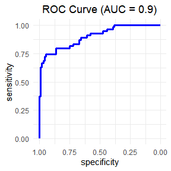

```r
# Plot ROC curve on the test set
plot_roc(y_test_iono, pred_score_iono_ker)
```

```r
# 5-fold CV for kernel models
cvfit_iono_ker <- cv.kroclearn(
  X_train_iono, y_train_iono,
  lambda.vec = exp(seq(log(0.01), log(5), length.out = 10)),
  kernel = "radial",
  approx=TRUE, nfolds=5)
summary(cvfit_iono_ker)
```

```
#> Cross-validated Kernel Model
#> ------------------------------
#> Loss: hinge
#> Kernel: radial
#> Number of folds: 5
#> Number of candidate lambdas: 10
#>
#> Optimal lambda: 0.01994737
#> Cross-validated AUC at optimal lambda: 0.9153 (+/- 0.0226)
#>
#> Overall AUC (mean +/- sd) across lambdas:
#>    lambda auc.mean auc.sd
#> 1  0.0100   0.8981 0.0560
#> 2  0.0199   0.9153 0.0226
#> 3  0.0398   0.8671 0.0773
#> 4  0.0794   0.8608 0.0530
#> 5  0.1580   0.8189 0.0580
#> 6  0.3160   0.8189 0.0665
#> 7  0.6300   0.7965 0.0450
#> 8  1.2600   0.7944 0.0879
#> 9  2.5100   0.8041 0.0649
#> 10 5.0000   0.8137 0.0387
```

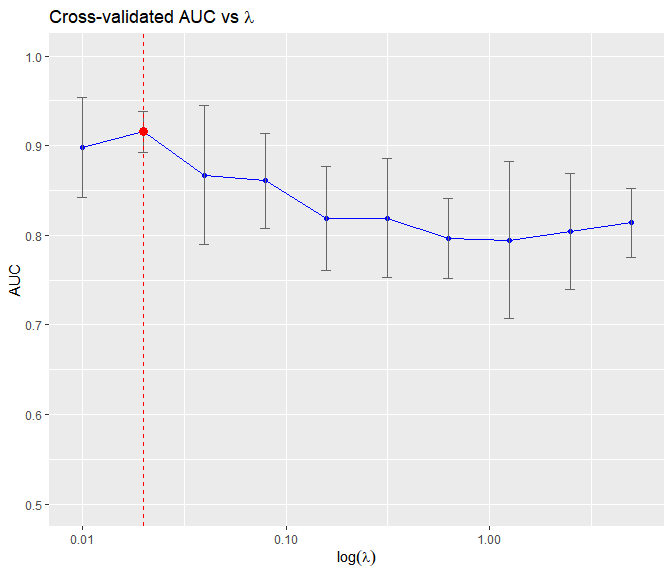

```r
# Plot the cross-validation AUC across lambda values
plot(cvfit_iono_ker)
```

# Real Data Example 2: Spam (larger dataset)

```r
library(kernlab)
data(spam)

# Prepare data
X_spam <- spam[, -58]
y_spam <- ifelse(spam$type == "spam", 1, -1)

set.seed(123)
train_idx <- sample(seq_len(nrow(X_spam)), size = 3000)
X_train_spam <- X_spam[train_idx, ]
y_train_spam <- y_spam[train_idx]
X_test_spam  <- X_spam[-train_idx, ]
y_test_spam  <- y_spam[-train_idx]

# Fit a linear model
fit_spam_lin <- roclearn(X_train_spam, y_train_spam, lambda = 0.1)
summary(fit_spam_lin)
```

```
#> Linear Model Summary
#> ----------------------
#> Call:
#> roclearn(X = X_train_spam, y = y_train_spam, lambda = 0.1)
#>
#> Number of observations: 3000
#> Number of predictors: 57
#>
#> Penalty: ridge
#> Lambda: 0.1
#> Loss function: hinge
#> Approximation: Yes (B = 3000 )
#>
#> Intercept: -0.5147
#> Converged: TRUE
#> Iterations: 10
#> Training time (sec): 0.02
#>
#> Coefficients (first 10):
#>          make       address           all         num3d           our
#>  4.321339e-06 -5.145267e-06  1.017238e-05  5.731498e-06  1.621501e-05
#>          over        remove      internet         order          mail
#>  5.582747e-06  1.344279e-05  7.710516e-06  3.596203e-06  7.202070e-06
#> ...
```

```r
# Predict decision scores on the test set
pred_score_spam_lin <- predict(fit_spam_lin, X_test_spam, type = "response")
head(pred_score_spam_lin)
```

```
#>          3          6          8         10         14         15
#> 10.4085857 -0.2464476 -0.2763554  2.8799679 -0.3900616  0.4386678
```

```r
# Predict classes {-1, 1} on the test set
pred_class_spam_lin <- predict(fit_spam_lin, X_test_spam, type = "class")
head(pred_class_spam_lin)
```

```
#>  3  6  8 10 14 15
#>  1 -1 -1  1 -1  1
```

```r
# AUC on the test set
auc(fit_spam_lin, X_test_spam, y_test_spam)
```

```
#> [1] 0.7624179
```

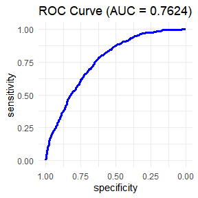

```r
# Plot ROC curve on the test set
plot_roc(y_test_spam, pred_score_spam_lin)
```

```r
# 5-fold CV for linear models
cvfit_spam_lin <- cv.roclearn(
  X_train_spam, y_train_spam,
  lambda.vec = exp(seq(log(0.01), log(5), length.out = 10)), nfolds=5)
summary(cvfit_spam_lin)
```

```
#> Cross-validated Linear Model
#> -----------------------
#> Loss: hinge
#> Penalty: ridge
#> Number of folds: 5
#> Number of candidate lambdas: 10
#>
#> Optimal lambda: 0.3158114
#> Cross-validated AUC at optimal lambda: 0.7777 (+/- 0.0232)
#>
#> Overall AUC (mean +/- sd) across lambdas:
#>    lambda auc.mean auc.sd
#> 1  0.0100   0.7715 0.0167
#> 2  0.0199   0.7764 0.0194
#> 3  0.0398   0.7741 0.0215
#> 4  0.0794   0.7748 0.0220
#> 5  0.1580   0.7758 0.0252
#> 6  0.3160   0.7777 0.0232
#> 7  0.6300   0.7735 0.0233
#> 8  1.2600   0.7753 0.0192
#> 9  2.5100   0.7715 0.0199
#> 10 5.0000   0.7722 0.0224
```

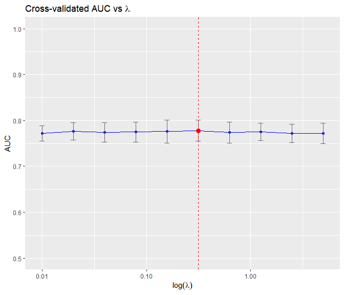

```r
# Plot the cross-validation AUC across lambda values
plot(cvfit_spam_lin)
```

```r
# Fit a kernel model
fit_spam_ker <- kroclearn(X_train_spam, y_train_spam, lambda = 0.1, kernel = "radial")
summary(fit_spam_ker)
```

```
#> Kernel Model Summary
#> -----------------------------
#> Call:
#> kroclearn(X = X_train_spam, y = y_train_spam, lambda = 0.1, kernel = "radial")
#>
#> Number of observations: 3000
#> Number of predictors: 57
#>
#> Kernel: radial
#> Kernel parameter: 0.01754386
#> Lambda: 0.1
#> Loss function: hinge
#> Approximation: Yes (Nystrom, B = 3000 )
#>   Nystrom landmarks: 55
#>
#> Intercept: 5e-04
#> Converged: TRUE
#> Iterations: 607
#> Training time (sec): 0.74
#>
#> Theta coefficients (first 10):
#>  [1] -0.106694761  0.034588410 -0.155193553 -0.091769201  0.008358426
#>  [6]  0.039672217 -0.191470994 -0.079506402  0.013024674 -0.468039804
#> ...
```

```r
# Predict decision scores on the test set
pred_score_spam_ker <- predict(fit_spam_ker, X_test_spam, type = "response")
head(pred_score_spam_ker)
```

```
#>             3             6             8            10            14
#>  0.0005386429 -0.0461043933 -0.1537764925  0.0005388521 -0.3817359714
#>            15
#>  0.0005386429
```

```r
# Predict classes {-1, 1} on the test set
pred_class_spam_ker <- predict(fit_spam_ker, X_test_spam, type = "class")
head(pred_class_spam_ker)
```

```
#>  3  6  8 10 14 15
#>  1 -1 -1  1 -1  1
```

```r
# AUC on the test set
auc(fit_spam_ker, X_test_spam, y_test_spam)
```

```
#> [1] 0.7513072
```

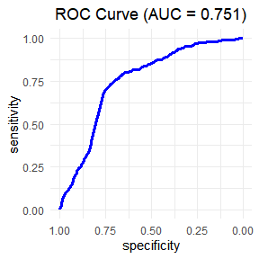

```r
# Plot ROC curve on the test set
plot_roc(y_test_spam, pred_score_spam_ker)
```

```r
# 5-fold CV for kernel models
cvfit_spam_ker <- cv.kroclearn(
  X_train_spam, y_train_spam,
  kernel = "radial",
  lambda.vec = exp(seq(log(0.01), log(5), length.out = 10)), nfolds=5)
summary(cvfit_spam_ker)
```

```
#> Cross-validated Kernel Model
#> ------------------------------
#> Loss: hinge
#> Kernel: radial
#> Number of folds: 5
#> Number of candidate lambdas: 10
#>
#> Optimal lambda: 5
#> Cross-validated AUC at optimal lambda: 0.7385 (+/- 0.0146)
#>
#> Overall AUC (mean +/- sd) across lambdas:
#>    lambda auc.mean auc.sd
#> 1  0.0100   0.7303 0.0146
#> 2  0.0199   0.7173 0.0339
#> 3  0.0398   0.7301 0.0139
#> 4  0.0794   0.7287 0.0167
#> 5  0.1580   0.7258 0.0184
#> 6  0.3160   0.7196 0.0162
#> 7  0.6300   0.7281 0.0295
#> 8  1.2600   0.7331 0.0168
#> 9  2.5100   0.7259 0.0292
#> 10 5.0000   0.7385 0.0146
```

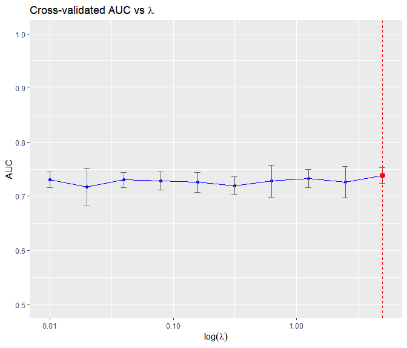

```r
# Plot the cross-validation AUC across lambda values
plot(cvfit_spam_ker)
```

# Conclusion

The **roclab** package implements ROC-Optimizing Binary Classifiers through both **linear models** (with regularization penalties) and **kernel models** (with various kernel functions). It supports multiple surrogate loss functions and incorporates scalable options to efficiently handle large datasets.